# Yoshita Aligina HW 2

1. Is it appropriate to use linear regression models to address each question in the following? Why and why not?
1. We COULD use linear regression models here in the case when we try to predict this using biological sex as a binary variable. However, this may not work if sex and age at death do not have a linear relationship.
2. I do not think it would be appropriate at all because the idea is people either do or don’t have diabetes, there isn’t an in between.
3. We couldn’t because we are expecting continuous results, which we would not receive in this sitution.
4. We could not because we are given three categoricaa values for the quality of the wine.

```r
library(foreign)
kidiq=read.dta("kidiq.dta")
```

1. In Code
2. In Code
3. The slope indicates the expected increase in score for children whose moms completed high school.
4. The intercept represents the average kid score for children whose moms did not complete high school.

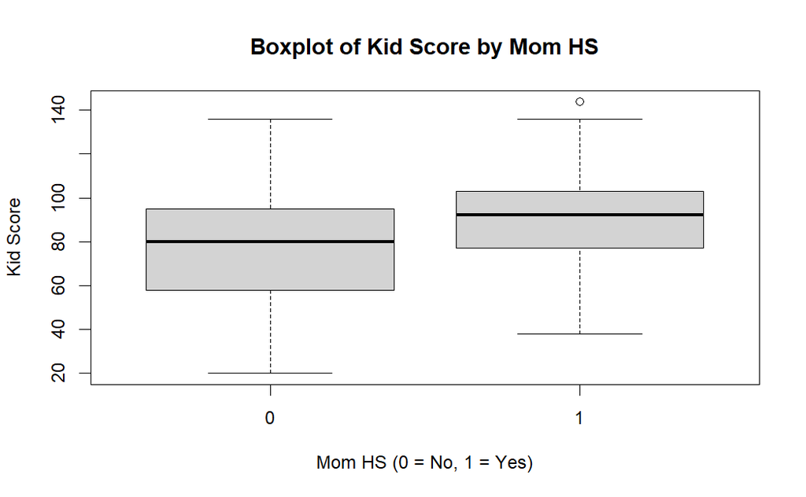

```r
#(a)
boxplot(kidiq$kid_score ~ kidiq$mom_hs,
        xlab = "Mom HS (0 = No, 1 = Yes)",
        ylab = "Kid Score",
        main = "Boxplot of Kid Score by Mom HS")
```

```r
#(b)
lm_model <- lm(kid_score ~ mom_hs, data = kidiq)
summary(lm_model)$coefficients
```

```
            Estimate Std. Error   t value      Pr(>|t|)
(Intercept) 77.54839   2.058612 37.670231 1.392224e-138
mom_hs      11.77126   2.322427  5.068516  5.956524e-07
```

3.Split the data into two subgroups, corresponding to mom hs=0 and mom hs=1 respectively. For each subgroup, use the Kid’s Score (kid score) and Mom’s Score (mom iq) as the response and predictor respectively, and do the following: (a) In Code (b) In Code (c) For both groups, the slope represents the expected increase in the kid’s score for how much higher the mother’s IQ is, it is proportional.

```r
#(a & b)
lm_0 <- lm(kid_score ~ mom_iq, data = subset_0)
lm_1 <- lm(kid_score ~ mom_iq, data = subset_1)

summary(lm_0)$coefficients
```

```
               Estimate Std. Error    t value     Pr(>|t|)
(Intercept) -11.4820211 14.6011166 -0.7863797 4.336881e-01
mom_iq        0.9688892  0.1574348  6.1542253 1.996806e-08
```

```r
summary(lm_1)$coefficients
```

```
              Estimate Std. Error  t value     Pr(>|t|)
(Intercept) 39.7862023  6.6634115 5.970846 5.956893e-09
mom_iq       0.4846145  0.0645168 7.511448 5.236618e-13
```

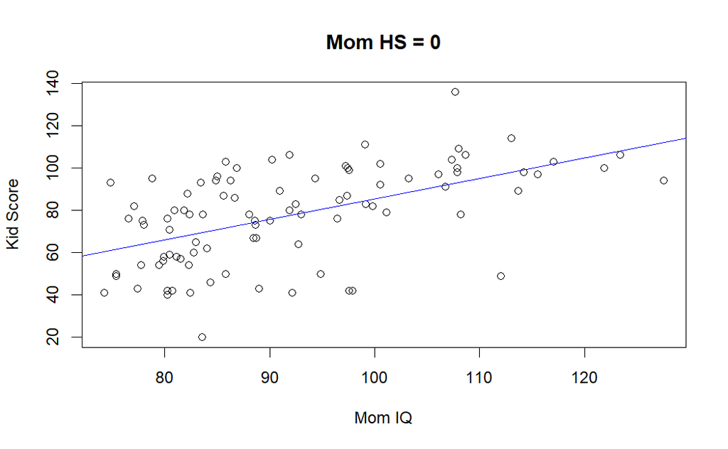

```r
plot(subset_0$mom_iq, subset_0$kid_score,
     xlab = "Mom IQ", ylab = "Kid Score",
     main = "Mom HS = 0")
abline(lm_0, col = "blue")
```

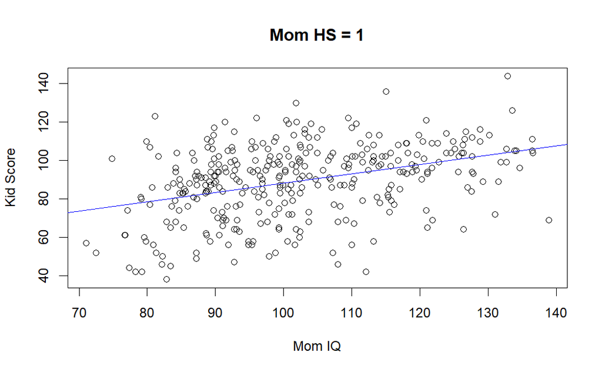

```r
plot(subset_1$mom_iq, subset_1$kid_score,
     xlab = "Mom IQ", ylab = "Kid Score",
     main = "Mom HS = 1")
abline(lm_1, col = "blue")
```